# Atividade 1 - Dados Pandemia Alagoas

# Alunos: Gabriel Luiz Leite Souza e João Victor Falcão Santos Lima

```r
# Lendo dados
alagoas <- read.csv('pandemia-alagoas.csv')

# Filtrando registros para Marechal Deodoro
marechal <- subset(alagoas, municipio_residencia == 'Marechal Deodoro')

dim(marechal)
```

```
## [1] 2421   15
```

## Item 1

### Variável qualitativa: sexo

```r
sexo.tb <- table(marechal$sexo)
```

### Gráfico de Barras

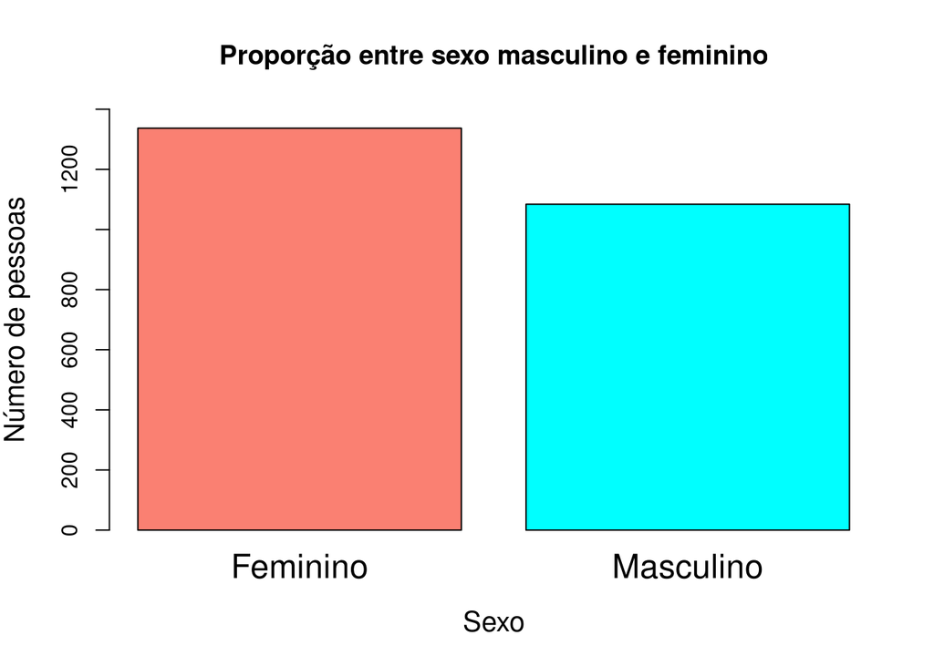

```r
#Grafico de Barras
barplot(sexo.tb, col = c("salmon", "cyan"),
        ylab = "Número de pessoas", xlab = "Sexo",
        cex.names = 1.5, cex.lab = 1.25, ylim=c(0,1400),
        main = "Proporção entre sexo masculino e feminino")
```

### Gráfico de Pizza

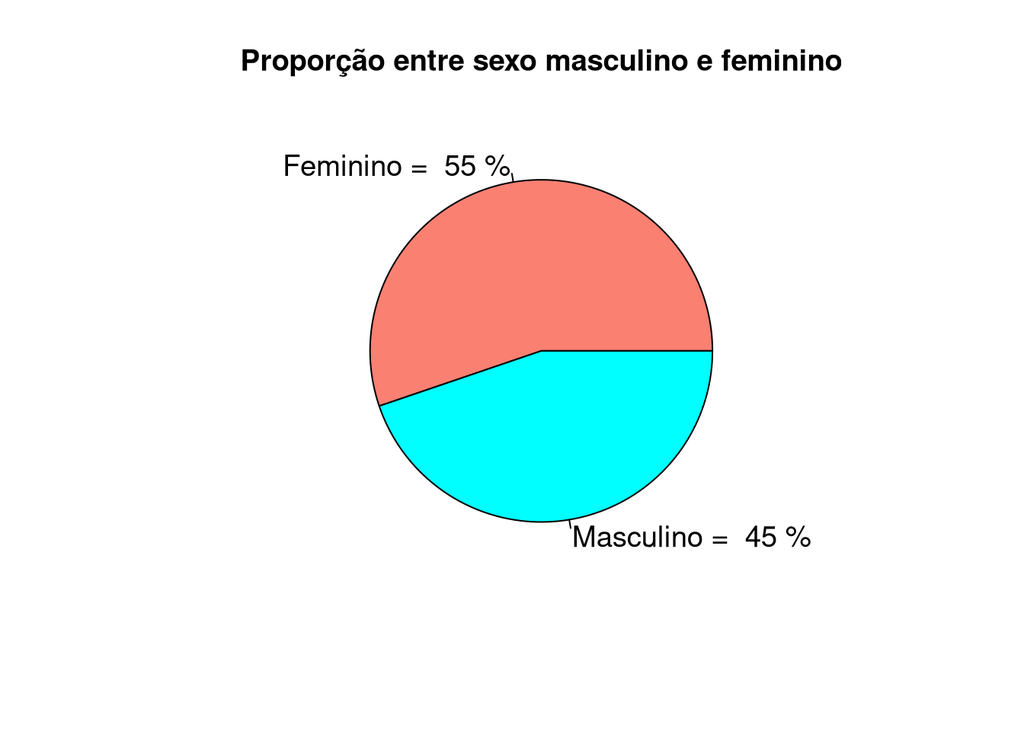

```r
# Grafico de Pizza
labs <- paste(c("Feminino = ", "Masculino = "),
              100 * round(sexo.tb/length(marechal$sexo), digits = 2),
              "%")

pie(sexo.tb, labels = labs,
    col = c("salmon", "cyan"),
    main = "Proporção entre sexo masculino e feminino",
    cex = 1.2)
```

## Item 2

### Variável contínua: idade

```r
# Variavel numerica: Idade
idade <- na.omit(as.numeric(marechal$idade))
#sort(idade)

# Amplitude de Classe
amplitude <- max(idade) - min(idade); amplitude
```

```
## [1] 104
```

```r
nk <- round(1 + 3.322 * log10(length(idade))); nk
```

```
## [1] 12
```

```r
ampClasse <- amplitude / nk; ampClasse; ampClasse <- 8.75
```

```
## [1] 8.666667
```

```r
limites = c(1, 9.75, 18.5, 27.25, 36, 44.75, 53.5,
            62.25, 71, 79.75, 88.5, 97.25, 106)

classes <- c("1.00-9.75", "9.75-18.50", "18.50-27.25", "27.25-36.00",
             "36.00-44.75", "44.75-53.50", "53.50-62.25", "62.25-71.00",
             "71.00-79.75", "79.75-88.50", "88.50-97.25", "97.25-106.00")

# Frequencia Absoluta
freq <- table(cut(idade, breaks = limites, right = FALSE, lables = classes))
freqAc <- cumsum(freq)

# Frequencia Relativa
freqRel <- prop.table(freq)
freqRelAc <- cumsum(freqRel)

# Tabela com todas as frequencias
tabResul = cbind(freq, freqAc, freqRel = round(freqRel*100, digits = 2),
                 freqRelAc = round(freqRelAc*100, digits = 2))
tabResul
```

```
##             freq freqAc freqRel freqRelAc
## [1,9.75)      20     20    0.83      0.83
## [9.75,18.5)   68     88    2.81      3.64
## [18.5,27.2)  362    450   14.98     18.62
## [27.2,36)    449    899   18.58     37.19
## [36,44.8)    570   1469   23.58     60.78
## [44.8,53.5)  463   1932   19.16     79.93
## [53.5,62.2)  272   2204   11.25     91.19
## [62.2,71)    122   2326    5.05     96.24
## [71,79.8)     60   2386    2.48     98.72
## [79.8,88.5)   24   2410    0.99     99.71
## [88.5,97.2)    6   2416    0.25     99.96
## [97.2,106)     1   2417    0.04    100.00
```

### Histograma

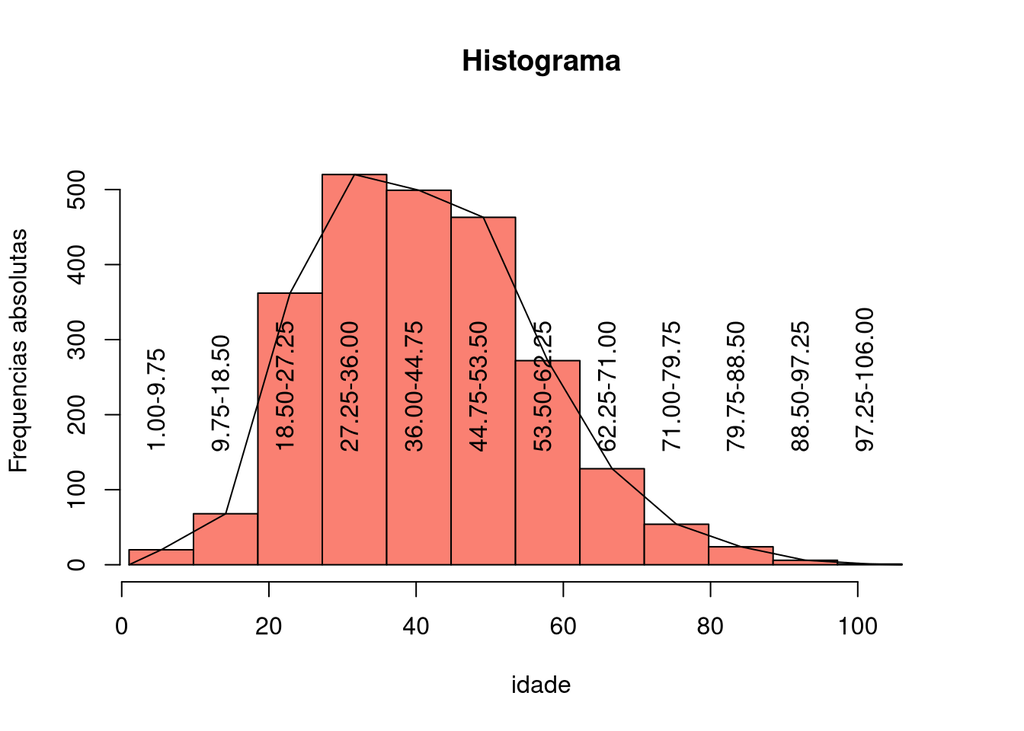

```r
# Histograma
h = hist(idade, breaks=limites,
         ylab="Frequencias absolutas",
         main="Histograma",
         xlim=c(4,110), ylim=c(0,570),
         col="salmon")
text(h$mids, 150, labels=classes, adj=c(0, 0.2), srt=90)

lines(c(min(h$breaks), h$mids, max(h$breaks)),
      c(0,h$counts, 0), type = "l")
```

## Item 3

### situacão = óbito vs febre, tosse, cefaleia e dificuldade respiratória

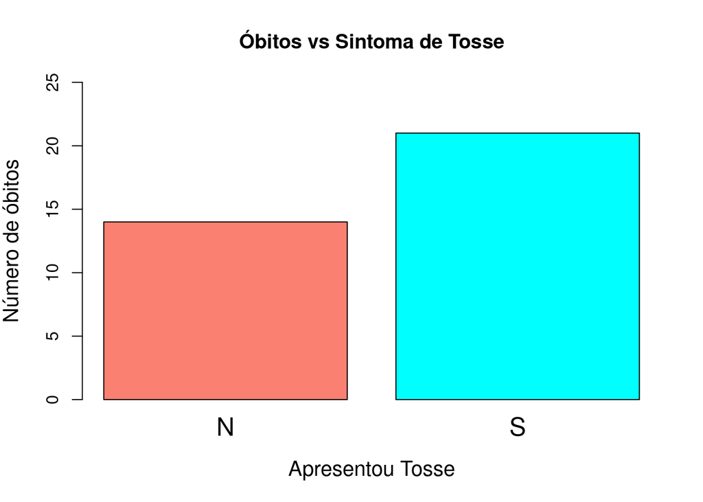

```r
obitos <- subset(marechal, situacao_atual == 'Óbito'
                 | situacao_atual == 'Obito')

obitos$tosse[obitos$tosse == ""] <- "N"
obitos$tosse[obitos$tosse == "X"] <- "S"
barplot(table(obitos$tosse), col = c("salmon", "cyan"),
        ylab = "Número de óbitos", xlab = "Apresentou Tosse",
        cex.names = 1.5, cex.lab = 1.25, ylim=c(0,25),
        main = "Óbitos vs Sintoma de Tosse")
```

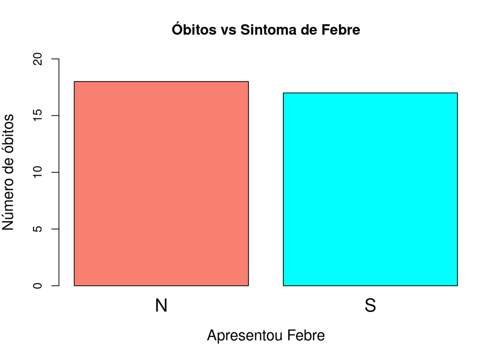

```r
obitos$febre[obitos$febre == ""] <- "N"
obitos$febre[obitos$febre == "X"] <- "S"
barplot(table(obitos$febre), col = c("salmon", "cyan"),
        ylab = "Número de óbitos", xlab = "Apresentou Febre",
        cex.names = 1.5, cex.lab = 1.25, ylim=c(0,20),
        main = "Óbitos vs Sintoma de Febre")
```

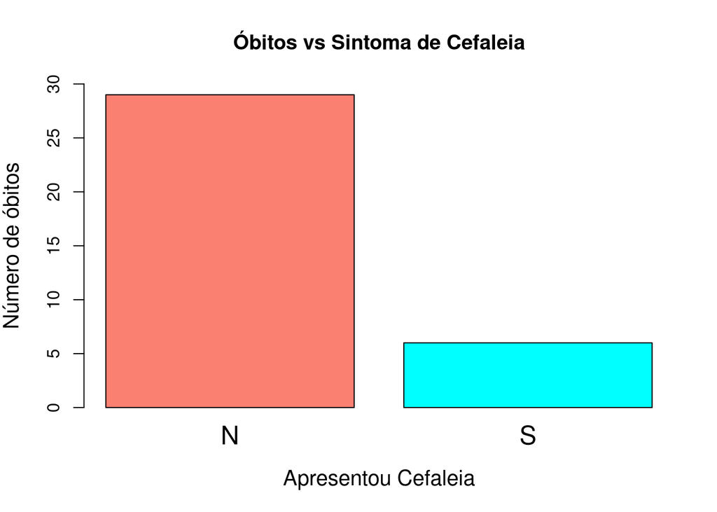

```r
obitos$cefaleia[obitos$cefaleia == ""] <- "N"
obitos$cefaleia[obitos$cefaleia == "X"] <- "S"
barplot(table(obitos$cefaleia), col = c("salmon", "cyan"),
        ylab = "Número de óbitos", xlab = "Apresentou Cefaleia",
        cex.names = 1.5, cex.lab = 1.25, ylim=c(0,30),
        main = "Óbitos vs Sintoma de Cefaleia")
```

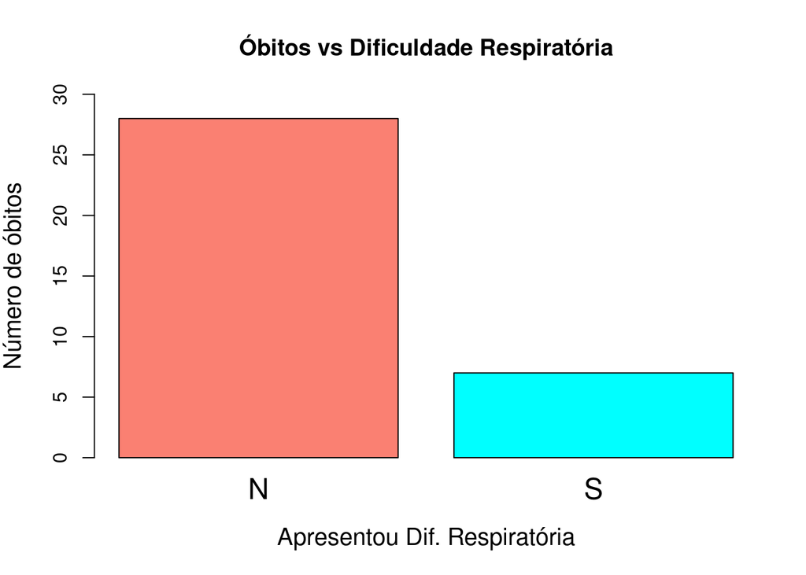

```r
obitos$dificuldade_respiratoria[obitos$dificuldade_respiratoria == ""] <- "N"
obitos$dificuldade_respiratoria[obitos$dificuldade_respiratoria == "X"] <- "S"
barplot(table(obitos$dificuldade_respiratoria), col = c("salmon", "cyan"),
        ylab = "Número de óbitos", xlab = "Apresentou Dif. Respiratória",
        cex.names = 1.5, cex.lab = 1.25, ylim=c(0,30),
        main = "Óbitos vs Dificuldade Respiratória")
```

### Item 4

### Variável qualitativa Sexo e variável quantitativa Idade

```r
# Boxplot sexo vs idade
# Classificacao dos quartis
quantile(marechal$idade, na.rm=TRUE)
```

```
##   0%  25%  50%  75% 100%
##    1   30   40   51  105
```

```r
idade.cut <- cut(marechal$idade,
                 breaks = quantile(marechal$idade, na.rm = TRUE),
                 include.lowest = TRUE)

# Tabela de frequencias absolutas
sexo.idade.tb <- table(marechal$sexo, idade.cut)
sexo.idade.tb
```

```
##            idade.cut
##             [1,30] (30,40] (40,51] (51,105]
##   Feminino     321     332     364      318
##   Masculino    307     262     254      259
```

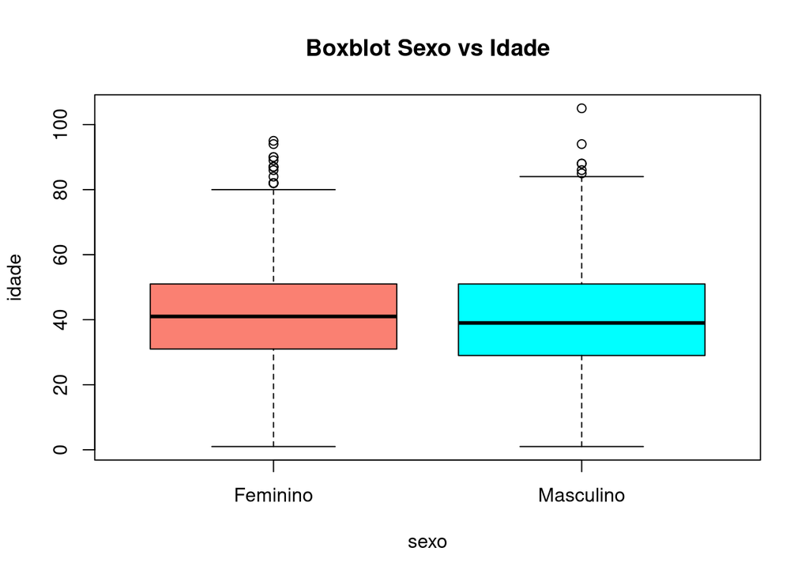

```r
# Boxplot
boxplot(idade ~ sexo, data = marechal,
        main = "Boxblot Sexo vs Idade",
        col = c("salmon", "cyan"))
```

## Item 5

### Interpretação sobre a idade (item 2)

#### De acordo com o gráfico Histograma plotado no item 2, pode-se notar a concentração de casos de covid principalmente nas idades entre 18.5 e 62.25 anos, ou seja, uma parcela economicamente ativa da população de Marechal Deodoro e que, possivelmente, esteve mais exposta ao vírus por ter que se deslocar e entrar em contato com mais pessoas para trabalhar.

### Interpretação sobre idade e sexo (item 4)

#### Como mostrado no item 1, a proporção entre pessoas do sexo feminino é de 55% e masculino 45%, aproximadamente. De acordo com o Boxplot do item 4, a posição dos dados para idade é próxima em ambos os sexos, com a mediana masculina sendo um pouco menor. Quanto à simetria, a mediana feminina posicionada bem ao centro da caixa indica dados simétricos, enquanto a masculina é um pouco inferior, indicando uma leve assimetria positiva dos dados. A dispersão, notada pelo tamanho da caixa, é bem aproximada em ambos os casos, mas a masculina é levemente maior. O limite superior masculino é maior, e o gráfico masculino apresenta outliers mais extremos, indicando casos em idades avançadas.